# Master 2 Biologie Santé

05/10/2026

## Who am I

- Ghislain Bidaut
- Research Engineer responsible of **CRCM Integrative Bioinformatics Platform** at the **Cancer Research Center of Marseille** **Centre de Recherche en Cancérologie de Marseille**
- Contact: ghislain.bidaut@inserm.fr
- Web: https://www.crcm-marseille.fr/equipes/plateformestechnologiques/plateforme-de-bioinformatique-integrative-cibi/

[figure not shown]

## Data classification and application in transcriptomics

### **Class discovery**

- *Hierarchical Clustering*

### **Dimension reduction**

- *Multidimensional analysis with Principal Component Analysis*

### **Applications**

Analysis of transcriptome data (RNA-seq) - Application of PCA analysis - Application of hierarchical clustering to RNA-seq - TCGA public data

### **Single Cell data analysis**

## Class Discovery

## Introduction to classification

- **Goal**: create classes
- **Class**: Group of individuals sharing main common characters.

*Example*: Phylogenetic tree

[figure not shown]

## Introduction to classification

*Example*: Computer File system

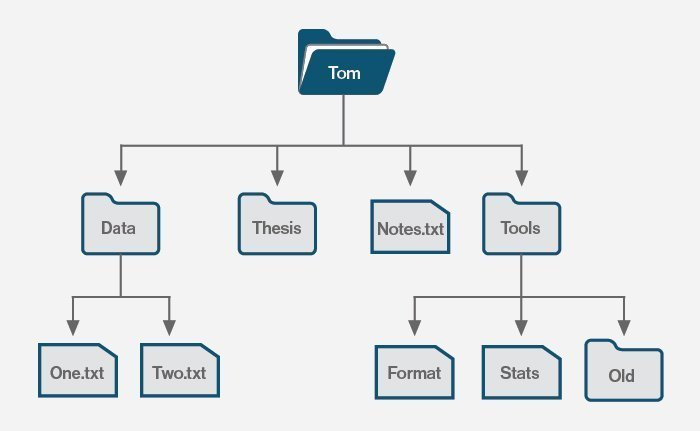

*Examples*: 2 types of classification:

- hierarchical (Ex: Clustering or *Classification Ascendante Hiérarchique*)
- Partitioning (Ex: *K-Means*)

## Data structure

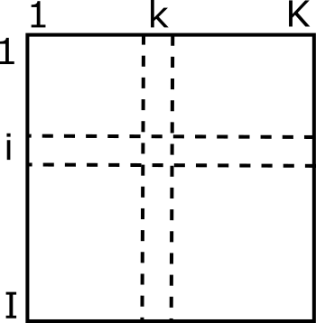

- Columns \(1...K\) variables
- Rows \(1...I\) individuals

## Examples of datasets

- **Economy**: value of indicator \(k\) for year \(i\)
- **Biology**: value of measure \(k\) for sample \(i\)
- **Social sciences**: revenue in interval \(k\) for scocio-professional categories \(i\)
- **Genetics (Transcriptomics)**: value of expression for gene \(k\) in patient \(i\)
  - Many genes (20k in human)
  - Low number of samples
- …

## Data structure in genomics

For practical reasons (**lots of variables, small number of individuals**), the data structure used in Genomics/Transcriptomics is **permuted**.

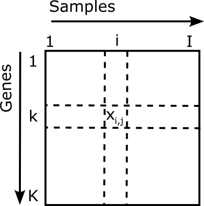

## Application to temperature data

*Thanks to F. Husson (INRIA).*

|  | Janu | Febr | Marc | Apri | May | June | July | Augu | Annu | Ampl | Lati | Long | Area |
| --- | --- | --- | --- | --- | --- | --- | --- | --- | --- | --- | --- | --- | --- |
| Amsterdam | 2.9 | 2.5 | 5.7 | 8.2 | 12.5 | 14.8 | 17.1 | 17.1 | 9.9 | 14.6 | 52.2 | 4.5 | West |
| Athens | 9.1 | 9.7 | 11.7 | 15.4 | 20.1 | 24.5 | 27.4 | 27.2 | 17.8 | 18.3 | 37.6 | 23.5 | South |
| Berlin | -0.2 | 0.1 | 4.4 | 8.2 | 13.8 | 16.0 | 18.3 | 18.0 | 9.1 | 18.5 | 52.3 | 13.2 | West |
| Brussels | 3.3 | 3.3 | 6.7 | 8.9 | 12.8 | 15.6 | 17.8 | 17.8 | 10.3 | 14.4 | 50.5 | 4.2 | West |
| Budapest | -1.1 | 0.8 | 5.5 | 11.6 | 17.0 | 20.2 | 22.0 | 21.3 | 10.9 | 23.1 | 47.3 | 19.0 | East |
| Copenhagen | -0.4 | -0.4 | 1.3 | 5.8 | 11.1 | 15.4 | 17.1 | 16.6 | 7.8 | 17.5 | 55.4 | 12.3 | North |
| Dublin | 4.8 | 5.0 | 5.9 | 7.8 | 10.4 | 13.3 | 15.0 | 14.6 | 9.3 | 10.2 | 53.2 | 6.1 | North |
| Elsinki | -5.8 | -6.2 | -2.7 | 3.1 | 10.2 | 14.0 | 17.2 | 14.9 | 4.8 | 23.4 | 60.1 | 25.0 | North |
| Kiev | -5.9 | -5.0 | -0.3 | 7.4 | 14.3 | 17.8 | 19.4 | 18.5 | 7.1 | 25.3 | 50.3 | 30.3 | East |
| Krakow | -3.7 | -2.0 | 1.9 | 7.9 | 13.2 | 16.9 | 18.4 | 17.6 | 7.7 | 22.1 | 50.0 | 19.6 | East |
| Lisbon | 10.5 | 11.3 | 12.8 | 14.5 | 16.7 | 19.4 | 21.5 | 21.9 | 15.9 | 11.4 | 38.4 | 9.1 | South |
| London | 3.4 | 4.2 | 5.5 | 8.3 | 11.9 | 15.1 | 16.9 | 16.5 | 9.7 | 13.5 | 51.4 | 0.0 | North |
| Madrid | 5.0 | 6.6 | 9.4 | 12.2 | 16.0 | 20.8 | 24.7 | 24.3 | 13.9 | 19.7 | 40.2 | 3.4 | South |
| Minsk | -6.9 | -6.2 | -1.9 | 5.4 | 12.4 | 15.9 | 17.4 | 16.3 | 5.5 | 24.3 | 53.5 | 27.3 | East |
| Moscow | -9.3 | -7.6 | -2.0 | 6.0 | 13.0 | 16.6 | 18.3 | 16.7 | 5.1 | 27.6 | 55.7 | 37.6 | East |

## Problem and objective

This table can be seen as a **series of rows** or a **series of column** and can be studied **either way**.

- Study of individuals: (group **similar individuals**)
- Study of variables (discover **links among variables**)

\(\Longrightarrow\) correlation matrix

\(\Longrightarrow\) discovery of indicators that summarize many variables

- *a priori*: example: **average**
- we work *a posteriori* (We transform the data then analyze it)

Links among the 2 dimensions:

**Automatic characterization of individuals through variables**.

## Objective of Hierarchical clustering

- Identify **links** between **individuals** or **group of individuals**
- Extract a **hierarchy**
- Detect **natural classes** among the individuals of a population

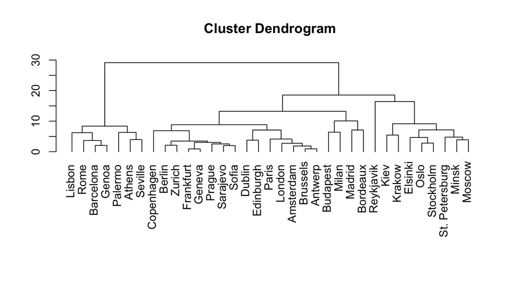

## Objectives of Hierarchical clustering

Identification of **natural groups** among individuals.

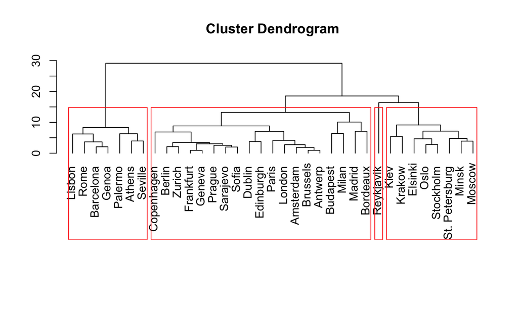

## Criteria

Resemblance among **individuals**

- Distance (ex *Euclidian distance*)
- Correlations (ex: *Pearson correlation*)
- Similarity indices (Ex: *Jaccard Index*)

Resemblance among **Groups of individuals**

- Single-linkage distance
- Complete-linkage distance
- Average distance

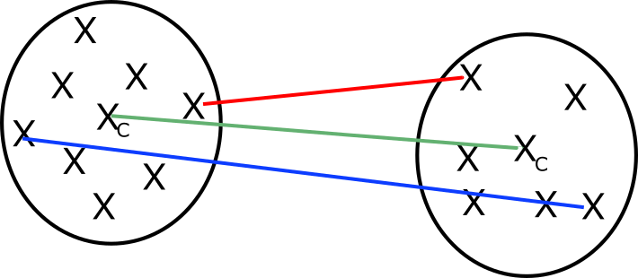

## Distance

There is a varety of **distance and correlations** measures, as well as **defining distances between groups** of individuals. The choice of these **changes** the final classification results.

The choice of using eiter one or the other **depends on the data** that we are analyzing.

It is calculated as a **vector operation** among 2 individuals. Example of the temperature dataset:

|  | Janu | Febr | Marc | Apri | May | June | July | Augu | Sept | Octo | Nove | Dece |
| --- | --- | --- | --- | --- | --- | --- | --- | --- | --- | --- | --- | --- |
| Amsterdam | 2.9 | 2.5 | 5.7 | 8.2 | 12.5 | 14.8 | 17.1 | 17.1 | 14.5 | 11.4 | 7.0 | 4.4 |
| Athens | 9.1 | 9.7 | 11.7 | 15.4 | 20.1 | 24.5 | 27.4 | 27.2 | 23.8 | 19.2 | 14.6 | 11.0 |

\(E(Amsterdam, Athens) = \sqrt{(2.9-9.1)^2+(2.5-9.7)^2+... + (4.4-11.0)^2}\)

## Several distances

- Euclidian Distance: \(E(x,y) = \sqrt{\sum_{i}(x_i-y_i)^2}\)
- Pearson Correlation: \(r(x,y) = \frac{n\sum{xy} - \sum{x}\sum{y}}{\sqrt{[n\sum{x}^2 - {n\sum{x}}^2].[n\sum{y}^2 - {n\sum{y}}^2]}}\)
- Jaccard Index or Jaccard similarity (useful for binary data, such as in Ecology)

\(J(x,y) = \frac{| A \cap B |}{ | A \cup B |}\)

\(J(x,y) = \frac{| A \cap B | }{ (| A | + | B | - | A \cap B | )}\)

## Jaccard Index

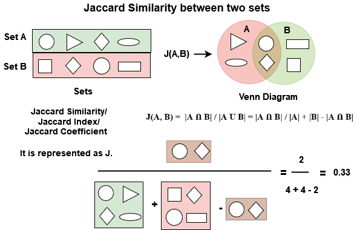

(*from* https://www.geeksforgeeks.org/how-to-calculate-jaccard-similarity-in-r/)

## Constructing a hierarchical tree

In the following slides, we will be constructing a hierarchical tree manually in order to understand all steps.

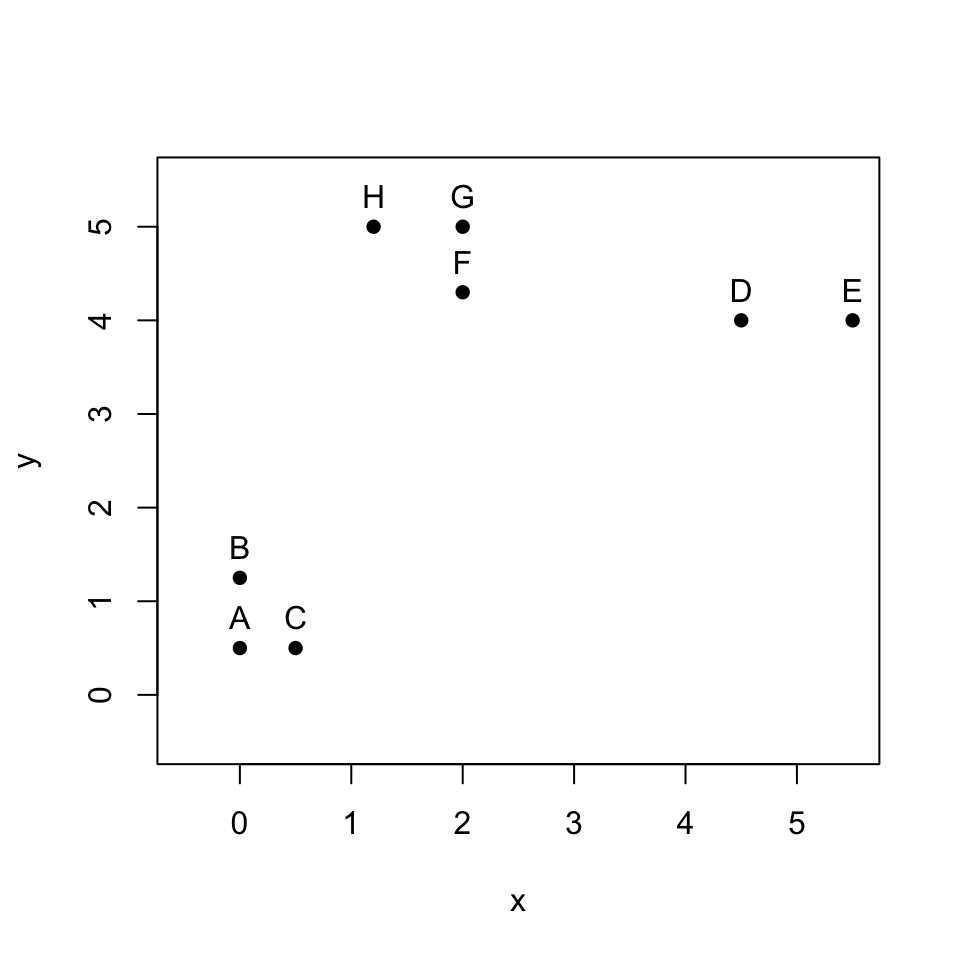

## Algorithm

1. **Calculate the pairwise distance matrix** for all of the individual to be clustered.
2. **Search the distance matrix for the two most similar individuals or clusters**. This is the true first stage in the “clustering” process. If several pairs share the same degree of similarity, a predetermined rule is used to decide between alternatives.
3. **The two selected clusters are merged to produce a new cluster** that now contains at two or more objects.
4. **The distances are calculated between this new cluster and all other clusters**. There is no need to calculate all distances since only those involving the new cluster have changed.
5. **Steps 2-4 are repeated** until all objects are **in one cluster**.

## Algorithm

Distance matrix among individuals. Here we calculated the **Euclidian** distance.

```
##      A    B    C    D    E    F    G
## B 0.75
## C 0.50 0.90
## D 5.70 5.27 5.32
## E 6.52 6.15 6.10 1.00
## F 4.29 3.65 4.09 2.52 3.51
## G 4.92 4.25 4.74 2.69 3.64 0.70
## H 4.66 3.94 4.55 3.45 4.41 1.06 0.80
```

## Representation

Typically, the relationship between samples is represented using a **Dendrogram**, where branches in the tree are built based on the connections determined between clusters as the algorithm progresses.

**Important:** In order to visualize the relationships between samples, the dendrogram is used to **rearrange** the rows (or columns as appropriate) in the data matrix to **visualize patterns** in the dataset.

## Hierarchical Tree Plot

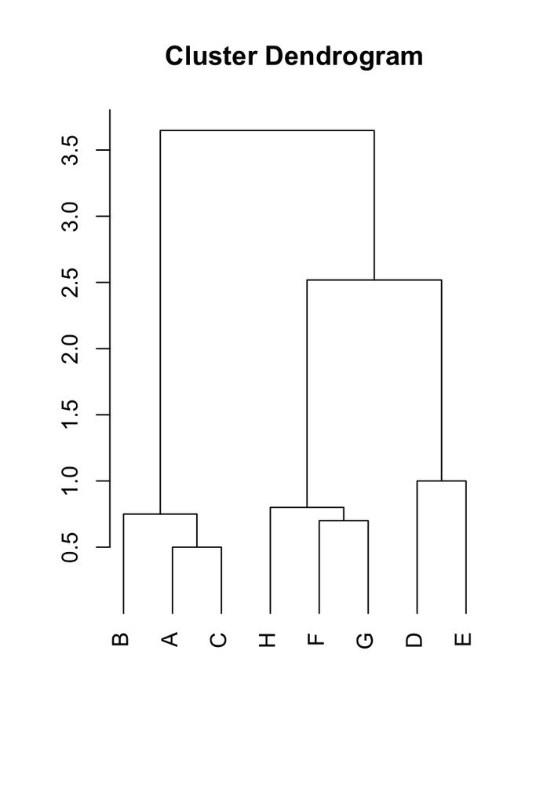

## Hierarchical clustering algorithm

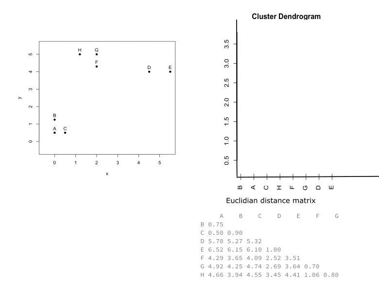

## Hierarchical clustering algorithm

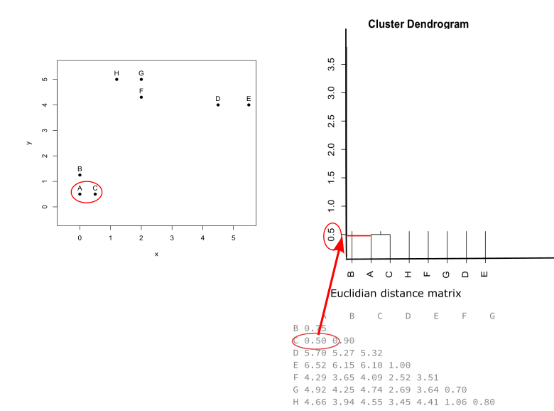

## Hierarchical clustering algorithm

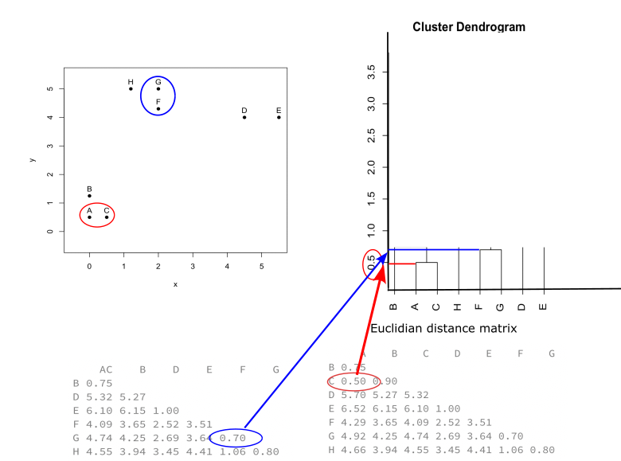

## Hierarchical clustering algorithm

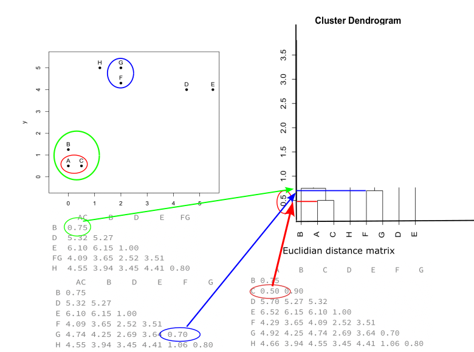

## Hierarchical clustering algorithm

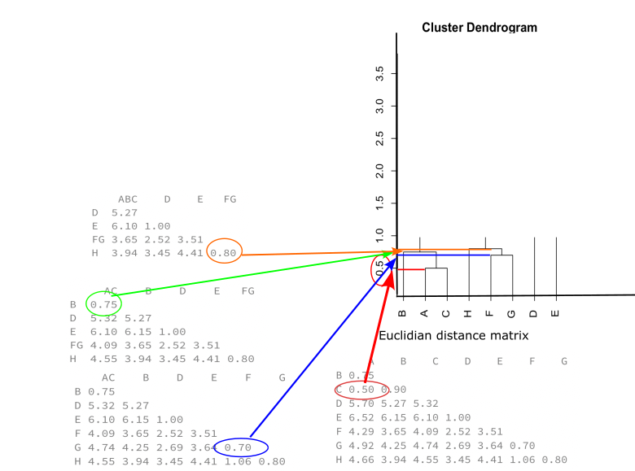

## Hierarchical clustering algorithm

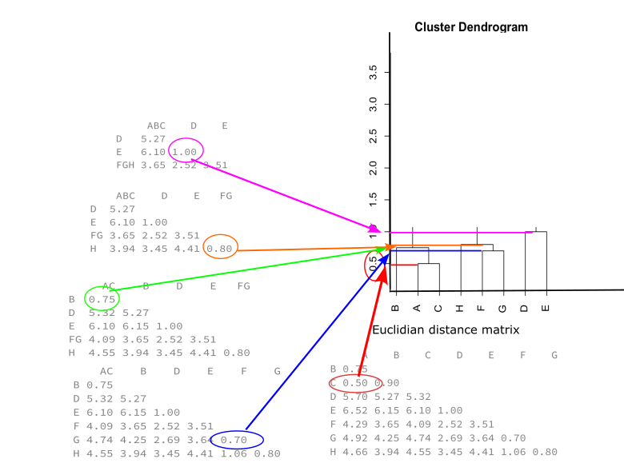

## Hierarchical clustering algorithm

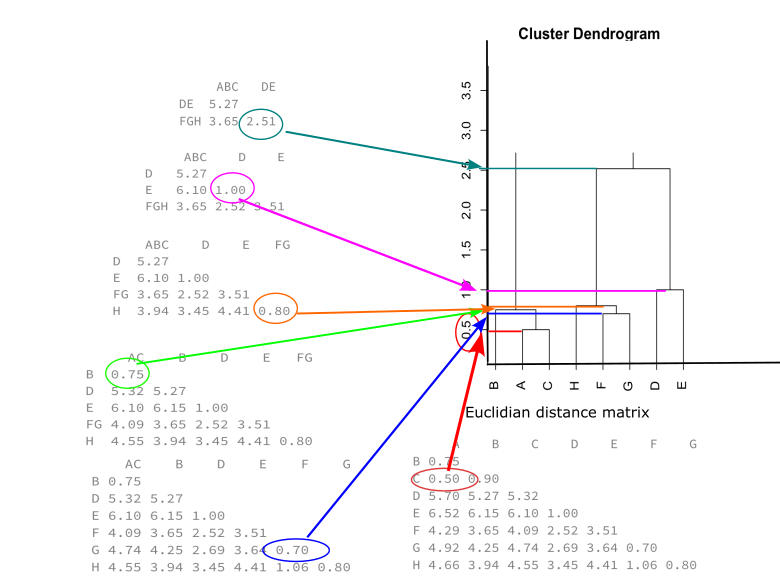

## Hierarchical clustering algorithm

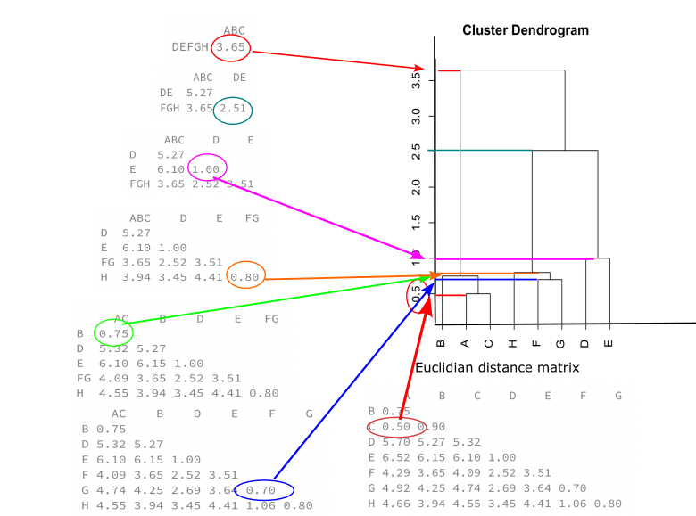

## Making partitions

Dendrograms, once built, can be cut in order to define data partitions.

Even if it is not always optimal, (due to the hierarchy construction) we usually obtain a good partition quality.

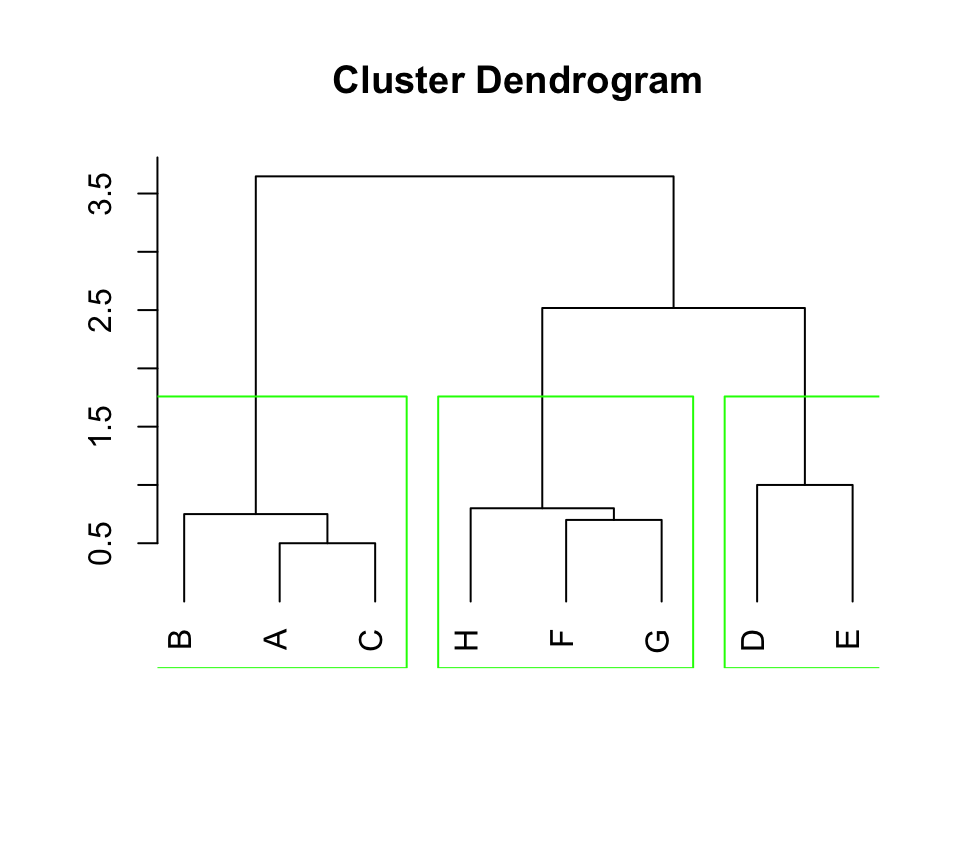

## Quality of a partition

A **partition is considered to be of good quality** if

- Individuals from the **same partitions** tend to be **similar** (Low *Inertia*)
- Individual from **different partitions** tend to be **different** (High *Inertia*)

Mathematically, this is verified by

- **Low intra-class** variance = low \(I_{intra}\)
- **Large inter-class** variance = high \(I_{inter}\)
- **Huyhens**: \(I_{tot} = I_{inter}+I_{intra}\)
- This is in fact a **single criteria**.

## Inertia Ratio

Partition quality is **optimal** when the ratio \(0 \leq \frac{I_{inter}}{I_{totale}} \leq 1\) is **maximum**.

- If \(\frac{I_{inter}}{I_{totale}} =0\) → \(\forall q, \overline{x_{qk}} = \overline{x_{k}}\)

  \(\Longrightarrow\) All classes have same average, **impossible to classify**
- If \(\frac{I_{inter}}{I_{totale}} = 1\) → \(\forall q, \forall i, x_{iqk} = \overline{x_{qk}}\)

  \(\Longrightarrow\) individuals are identical in each class, **ideal for classification**

! This criteria is **not absolute** since it depends on **the number of individuals** and **the number of classes**.

\(\rightarrow\) This is used by the *Ward methods* for discovering partitions in the data.

## Application to temperature data

|  | Janu | Febr | Marc | Apri | May | June | July | Augu | Annu | Ampl | Lati | Long | Area |
| --- | --- | --- | --- | --- | --- | --- | --- | --- | --- | --- | --- | --- | --- |
| Amsterdam | 2.9 | 2.5 | 5.7 | 8.2 | 12.5 | 14.8 | 17.1 | 17.1 | 9.9 | 14.6 | 52.2 | 4.5 | West |
| Athens | 9.1 | 9.7 | 11.7 | 15.4 | 20.1 | 24.5 | 27.4 | 27.2 | 17.8 | 18.3 | 37.6 | 23.5 | South |
| Berlin | -0.2 | 0.1 | 4.4 | 8.2 | 13.8 | 16.0 | 18.3 | 18.0 | 9.1 | 18.5 | 52.3 | 13.2 | West |
| Brussels | 3.3 | 3.3 | 6.7 | 8.9 | 12.8 | 15.6 | 17.8 | 17.8 | 10.3 | 14.4 | 50.5 | 4.2 | West |
| Budapest | -1.1 | 0.8 | 5.5 | 11.6 | 17.0 | 20.2 | 22.0 | 21.3 | 10.9 | 23.1 | 47.3 | 19.0 | East |
| Copenhagen | -0.4 | -0.4 | 1.3 | 5.8 | 11.1 | 15.4 | 17.1 | 16.6 | 7.8 | 17.5 | 55.4 | 12.3 | North |
| Dublin | 4.8 | 5.0 | 5.9 | 7.8 | 10.4 | 13.3 | 15.0 | 14.6 | 9.3 | 10.2 | 53.2 | 6.1 | North |
| Elsinki | -5.8 | -6.2 | -2.7 | 3.1 | 10.2 | 14.0 | 17.2 | 14.9 | 4.8 | 23.4 | 60.1 | 25.0 | North |
| Kiev | -5.9 | -5.0 | -0.3 | 7.4 | 14.3 | 17.8 | 19.4 | 18.5 | 7.1 | 25.3 | 50.3 | 30.3 | East |
| Krakow | -3.7 | -2.0 | 1.9 | 7.9 | 13.2 | 16.9 | 18.4 | 17.6 | 7.7 | 22.1 | 50.0 | 19.6 | East |
| Lisbon | 10.5 | 11.3 | 12.8 | 14.5 | 16.7 | 19.4 | 21.5 | 21.9 | 15.9 | 11.4 | 38.4 | 9.1 | South |
| London | 3.4 | 4.2 | 5.5 | 8.3 | 11.9 | 15.1 | 16.9 | 16.5 | 9.7 | 13.5 | 51.4 | 0.0 | North |
| Madrid | 5.0 | 6.6 | 9.4 | 12.2 | 16.0 | 20.8 | 24.7 | 24.3 | 13.9 | 19.7 | 40.2 | 3.4 | South |
| Minsk | -6.9 | -6.2 | -1.9 | 5.4 | 12.4 | 15.9 | 17.4 | 16.3 | 5.5 | 24.3 | 53.5 | 27.3 | East |
| Moscow | -9.3 | -7.6 | -2.0 | 6.0 | 13.0 | 16.6 | 18.3 | 16.7 | 5.1 | 27.6 | 55.7 | 37.6 | East |

## Clustering

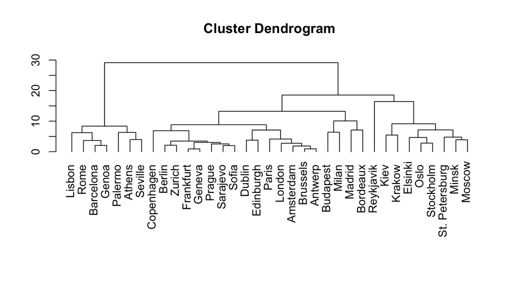

## Inertia

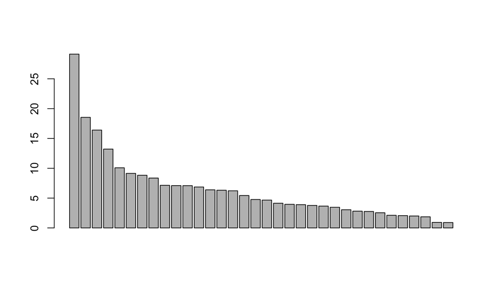

## Interpreting Inertia

**Inertia** corresponds to the **merge heights** in hierarchical clustering. Each height represents the **dissimilarity level** at which two clusters were merged.

- During hierarchical clustering, clusters are **merged step by step**.
- At every merge, the algorithm records a **height** (the distance between merged clusters).

**Breaks** in the curve gives hints on **data dimensionnality**.

## Clustering and groups

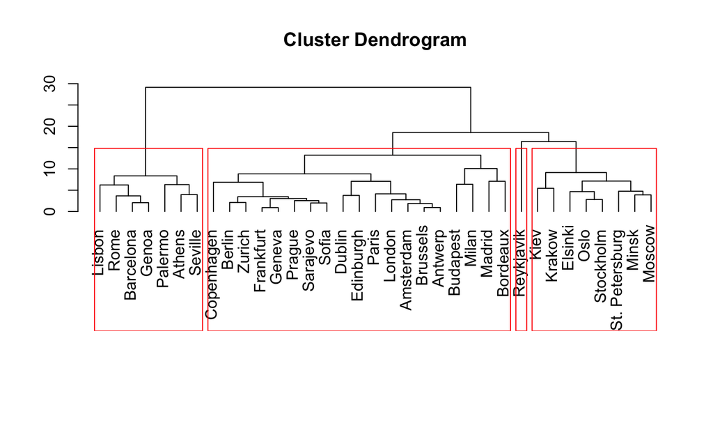

## Conclusion on clustering

- **Hierarchical clustering** is an interesting method to discover links among individuals and natural groups in the data.
- It can be used to partition the data with the underlying question: how many **groups** or **cluster** shall I partition my data into ?
- The analysis of **inertia** can aid in discovering the number of data groups.
- A manual analysis of the **dendrogram** can be sufficient if we have *previous* data knowledge.

## Dimension Reduction

## Multidimensional analysis with Principal Component Analysis

**Principal Component Analysis** goal is to provide a statistical description of large dimensional datasets and discover data structure:

- Links between **samples** (**groups or partitions**)
- Links between **variables**
- Links between **sample and variables**
- How can **supplementary variables** be interpreted or aid in data interpretation ?

## Data structure

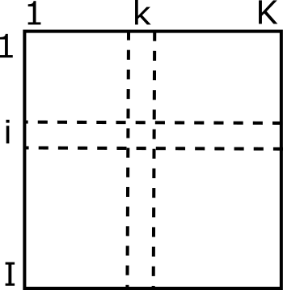

- Columns \(1...K\) variables
- Rows \(1...I\) individuals
- For the variable \(k\), we have
  - Mean \(\overline x_k = \frac{1}{I}\sum_{i=1}^{I}x_{ik}\)
  - Standard deviation \(s_k=\sqrt{\frac{1}{I}\sum_{i=1}^{I}(x_{ik}-\overline x_k)^2}\)

## PCA data exploration

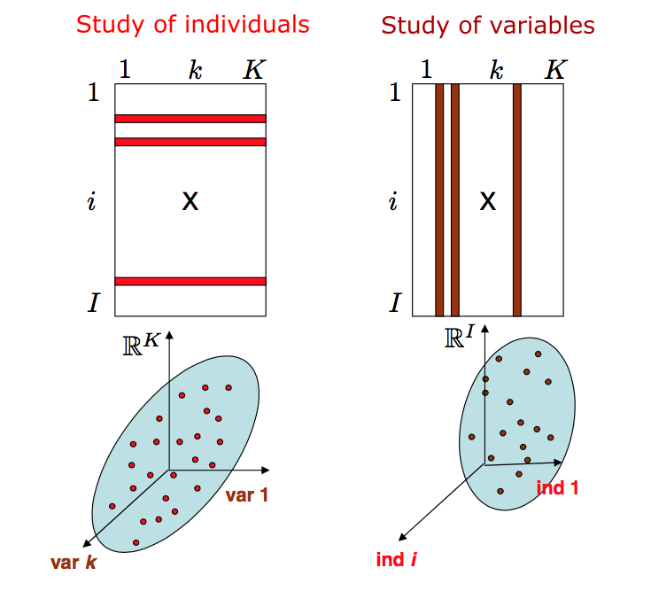

## Representing a multidimensional dataset as a cloud

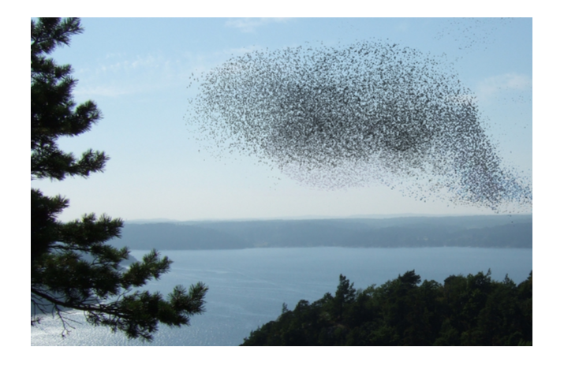

Représentation in \(R^K\). (*Figure : F. Husson*) The data cloud structure reflect the links among individuals.

## Pre-processing: Center and Reduce

Centering does not modify the cloud (\(\Longrightarrow\) Always center).

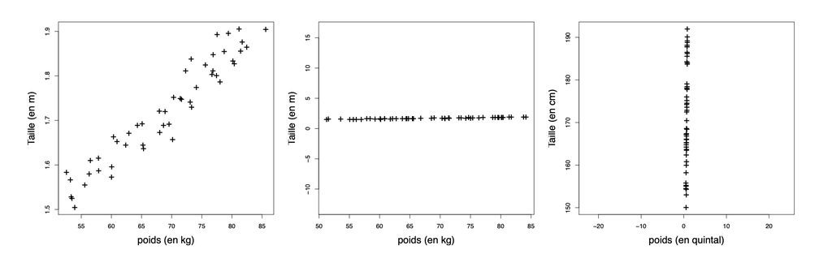

We must **reduce** data if **units are different** between variables.

Standardization/normalization: \(x_{ik} = \frac{x_{ik}-\overline x_k}{s_k}\).

**Importance** of a variable is **proportional** to its **standard deviation \(s\)**. (Figure : F. Husson)

## Temperature data

|  | Janu | Febr | Marc | Apri | May | June | July | Augu | Sept | Octo | Nove | Dece |
| --- | --- | --- | --- | --- | --- | --- | --- | --- | --- | --- | --- | --- |
| Amsterdam | 0.28 | 0.05 | 0.10 | -0.28 | -0.43 | -0.79 | -0.71 | -0.50 | -0.28 | 0.09 | 0.20 | 0.31 |
| Athens | 1.41 | 1.36 | 1.33 | 1.61 | 1.89 | 2.13 | 2.18 | 2.20 | 1.99 | 1.90 | 1.87 | 1.63 |
| Berlin | -0.28 | -0.39 | -0.17 | -0.28 | -0.03 | -0.43 | -0.37 | -0.26 | -0.30 | -0.23 | -0.41 | -0.34 |
| Brussels | 0.36 | 0.20 | 0.30 | -0.10 | -0.34 | -0.55 | -0.51 | -0.32 | -0.15 | 0.02 | 0.14 | 0.31 |
| Budapest | -0.44 | -0.26 | 0.06 | 0.61 | 0.94 | 0.84 | 0.66 | 0.62 | 0.31 | 0.07 | -0.21 | -0.44 |
| Copenhagen | -0.32 | -0.48 | -0.81 | -0.91 | -0.86 | -0.61 | -0.71 | -0.64 | -0.57 | -0.51 | -0.43 | -0.32 |
| Dublin | 0.63 | 0.51 | 0.14 | -0.39 | -1.07 | -1.24 | -1.29 | -1.17 | -0.71 | -0.30 | 0.14 | 0.51 |
| Elsinki | -1.30 | -1.53 | -1.63 | -1.62 | -1.13 | -1.03 | -0.68 | -1.09 | -1.44 | -1.34 | -1.31 | -1.04 |
| Kiev | -1.32 | -1.31 | -1.14 | -0.49 | 0.12 | 0.12 | -0.06 | -0.13 | -0.47 | -0.81 | -1.07 | -1.30 |
| Krakow | -0.92 | -0.77 | -0.68 | -0.36 | -0.22 | -0.15 | -0.34 | -0.37 | -0.47 | -0.56 | -0.76 | -0.92 |
| Lisbon | 1.66 | 1.65 | 1.56 | 1.37 | 0.85 | 0.60 | 0.53 | 0.78 | 1.16 | 1.48 | 1.67 | 1.65 |
| London | 0.37 | 0.36 | 0.06 | -0.26 | -0.61 | -0.70 | -0.76 | -0.67 | -0.40 | -0.19 | 0.05 | 0.31 |
| Madrid | 0.66 | 0.80 | 0.86 | 0.77 | 0.64 | 1.02 | 1.42 | 1.43 | 1.01 | 0.67 | 0.58 | 0.51 |
| Minsk | -1.50 | -1.53 | -1.47 | -1.02 | -0.46 | -0.46 | -0.62 | -0.72 | -0.98 | -1.20 | -1.31 | -1.43 |
| Moscow | -1.93 | -1.79 | -1.49 | -0.86 | -0.28 | -0.25 | -0.37 | -0.61 | -1.08 | -1.37 | -1.57 | -1.79 |

- **PCA:** analysis of **normalized** data (**standardized**).
- Complex visualization in \(K=12\) dimensions. PCA will **summarize** the data.

## Several projections

We are trying to find the **best** projection in order to **interpret** the data. A good **projection** gives a **simpler image** that contains the **bulk** of the information.

To achieve this, we identify the **projection** that gives the general form of the data cloud.

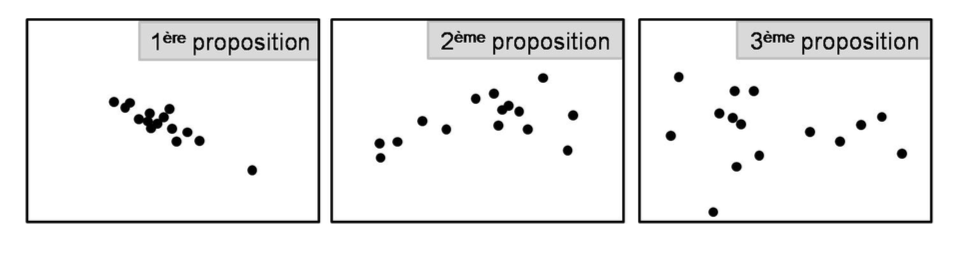

(*Figure: F. Husson*)

**Quantification** of the quality of a projection with **variance**, also called **inertia** on multiple dimensions.

## Ajusting individuals data cloud

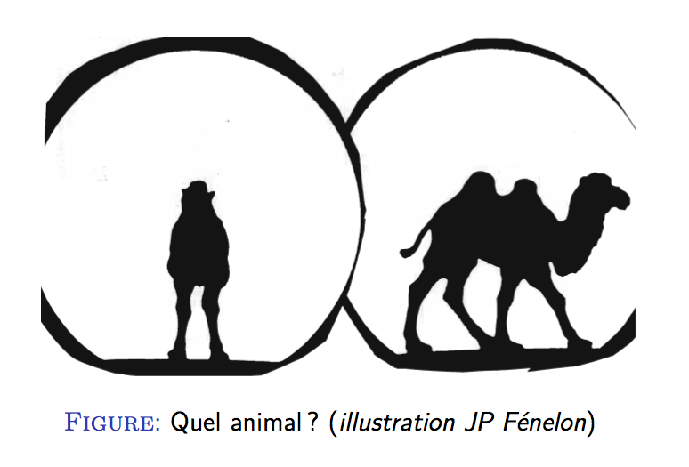

## Ajusting individuals data cloud

How to find the best projection ?

- **Find the best axis** that lower deformation to the image when projected on.

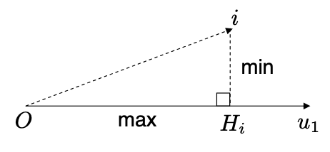

We want \((iH_i)^2, H_i \in axe\) small \(\Longrightarrow\) Pythagore \(\Longrightarrow\) \((OH_i)^2\) large.

We want to maximize \(\sum_{i}(OH_i)^2\).

- **Find the best 2D plan** that maximizes \(\sum_{i}(OH_i)^2\) with \(H_i \in plan\). We already have the bast axis \(ui_1\). We find \(u_2 \perp u_1\) maximizing \(\sum_{i}(OH_i)^2\)
- **Find the Third axis**: \(u_3 \perp u_2 \perp u_1\)
- **4th axis**, etc…

## Temperature data

- **Variables** (temperatures)
- **Quantified supplementary variables** (average, amplitude, Lat, long)
- **Qualitative supplementary variables** (area)

|  | Janu | Febr | Marc | Apri | May | June | July | Augu | Annu | Ampl | Lati | Long | Area |
| --- | --- | --- | --- | --- | --- | --- | --- | --- | --- | --- | --- | --- | --- |
| Amsterdam | 2.9 | 2.5 | 5.7 | 8.2 | 12.5 | 14.8 | 17.1 | 17.1 | 9.9 | 14.6 | 52.2 | 4.5 | West |
| Athens | 9.1 | 9.7 | 11.7 | 15.4 | 20.1 | 24.5 | 27.4 | 27.2 | 17.8 | 18.3 | 37.6 | 23.5 | South |
| Berlin | -0.2 | 0.1 | 4.4 | 8.2 | 13.8 | 16.0 | 18.3 | 18.0 | 9.1 | 18.5 | 52.3 | 13.2 | West |
| Brussels | 3.3 | 3.3 | 6.7 | 8.9 | 12.8 | 15.6 | 17.8 | 17.8 | 10.3 | 14.4 | 50.5 | 4.2 | West |
| Budapest | -1.1 | 0.8 | 5.5 | 11.6 | 17.0 | 20.2 | 22.0 | 21.3 | 10.9 | 23.1 | 47.3 | 19.0 | East |
| Copenhagen | -0.4 | -0.4 | 1.3 | 5.8 | 11.1 | 15.4 | 17.1 | 16.6 | 7.8 | 17.5 | 55.4 | 12.3 | North |
| Dublin | 4.8 | 5.0 | 5.9 | 7.8 | 10.4 | 13.3 | 15.0 | 14.6 | 9.3 | 10.2 | 53.2 | 6.1 | North |
| Elsinki | -5.8 | -6.2 | -2.7 | 3.1 | 10.2 | 14.0 | 17.2 | 14.9 | 4.8 | 23.4 | 60.1 | 25.0 | North |
| Kiev | -5.9 | -5.0 | -0.3 | 7.4 | 14.3 | 17.8 | 19.4 | 18.5 | 7.1 | 25.3 | 50.3 | 30.3 | East |
| Krakow | -3.7 | -2.0 | 1.9 | 7.9 | 13.2 | 16.9 | 18.4 | 17.6 | 7.7 | 22.1 | 50.0 | 19.6 | East |
| Lisbon | 10.5 | 11.3 | 12.8 | 14.5 | 16.7 | 19.4 | 21.5 | 21.9 | 15.9 | 11.4 | 38.4 | 9.1 | South |
| London | 3.4 | 4.2 | 5.5 | 8.3 | 11.9 | 15.1 | 16.9 | 16.5 | 9.7 | 13.5 | 51.4 | 0.0 | North |
| Madrid | 5.0 | 6.6 | 9.4 | 12.2 | 16.0 | 20.8 | 24.7 | 24.3 | 13.9 | 19.7 | 40.2 | 3.4 | South |
| Minsk | -6.9 | -6.2 | -1.9 | 5.4 | 12.4 | 15.9 | 17.4 | 16.3 | 5.5 | 24.3 | 53.5 | 27.3 | East |
| Moscow | -9.3 | -7.6 | -2.0 | 6.0 | 13.0 | 16.6 | 18.3 | 16.7 | 5.1 | 27.6 | 55.7 | 37.6 | East |

## PCA on temperature data (Graph of individuals)

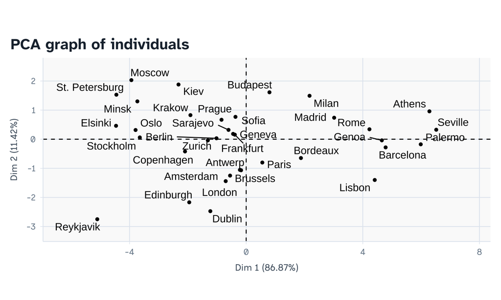

## Interpretation with variables

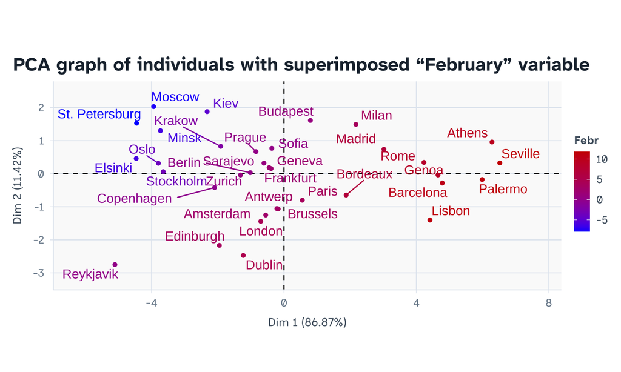